# Project: Medical No-show Appointments Data Analysis

- Introduction
- Data Wrangling
- Exploratory Data Analysis
- Conclusions

## Introduction

### Dataset Description

> This dataset comprises data gathered from 100,000 medical appointments in Brazil, with a primary focus on determining whether patients attend their scheduled appointments or not. This dataset has one table only and the introduction for each column within this dataset is listed below: 01 - PatientId : Identifier of each patient, it can be duplicated if they booked mutple times in the past. 02 - AppointmentID : Unique Identifier of each appointment 03 - Gender : Male or Female. In terms of gender distribution, females represent the majority in this dataset. Women demonstrate a higher level of attentiveness towards their health compared to men. 04 - ScheduledDay : The date that patients scheduled the appoinments. 05 - AppointmentDay : The date that patients booked for the visits. 06 - Age : How old is the patient. 07 - Neighbourhood : The location or venue of the appointments. 08 - Scholarship : 0 or 1 (True or False). 09 - Hipertension : 0 or 1 (True orFalse). 10 - Diabetes : 0 or 1 (True or False). 11 - Alcoholism : 0 or 1 (True or False). 12 - Handcap : 0 or 1 (True or False). 13 - SMS_received : 0 or 1 (True or False). 14 - No-show : No or Yes (True or False).

### Question(s) for Analysis

> 1. Was there a lower likelihood of appointment no-shows among individuals who received SMS text messages compared to those who did not receive them?
> 2. Was there a correlation between individuals aged over 37 (mean age) and their tendency to miss appointments, in comparison to those who were younger?
> 3. Was there a greater inclination among women or men to fail to show up for their appointments?

```python
# Import necessary packages and load `KaggleV2-May-2016.csv`
import pandas as pd
import numpy as np
import matplotlib.pyplot as plt
%matplotlib inline
import matplotlib.ticker as mticker
import seaborn as sns
df = pd.read_csv('KaggleV2-May-2016.csv')
```

```python
# Upgrade pandas to use dataframe.explode() function.
# !pip install --upgrade pandas==0.25.0
```

[output not shown]

## Data Wrangling

```python
# Exploring dataset to to have an overview and ask correct questions
df.head()
```

|  | PatientId | AppointmentID | Gender | ScheduledDay | AppointmentDay | Age | Neighbourhood | Scholarship | Hipertension | Diabetes | Alcoholism | Handcap | SMS_received | No-show |
| --- | --- | --- | --- | --- | --- | --- | --- | --- | --- | --- | --- | --- | --- | --- |
| 0 | 2.987250e+13 | 5642903 | F | 2016-04-29T18:38:08Z | 2016-04-29T00:00:00Z | 62 | JARDIM DA PENHA | 0 | 1 | 0 | 0 | 0 | 0 | No |
| 1 | 5.589978e+14 | 5642503 | M | 2016-04-29T16:08:27Z | 2016-04-29T00:00:00Z | 56 | JARDIM DA PENHA | 0 | 0 | 0 | 0 | 0 | 0 | No |
| 2 | 4.262962e+12 | 5642549 | F | 2016-04-29T16:19:04Z | 2016-04-29T00:00:00Z | 62 | MATA DA PRAIA | 0 | 0 | 0 | 0 | 0 | 0 | No |
| 3 | 8.679512e+11 | 5642828 | F | 2016-04-29T17:29:31Z | 2016-04-29T00:00:00Z | 8 | PONTAL DE CAMBURI | 0 | 0 | 0 | 0 | 0 | 0 | No |
| 4 | 8.841186e+12 | 5642494 | F | 2016-04-29T16:07:23Z | 2016-04-29T00:00:00Z | 56 | JARDIM DA PENHA | 0 | 1 | 1 | 0 | 0 | 0 | No |

From this step, we found that we need to convert the PatientId column from scientific notation to an int format in order to present it correctly.

```python
# Checking if there's any missing values
df.info()
```

```
<class 'pandas.core.frame.DataFrame'>
RangeIndex: 110527 entries, 0 to 110526
Data columns (total 14 columns):
PatientId         110527 non-null float64
AppointmentID     110527 non-null int64
Gender            110527 non-null object
ScheduledDay      110527 non-null object
AppointmentDay    110527 non-null object
Age               110527 non-null int64
Neighbourhood     110527 non-null object
Scholarship       110527 non-null int64
Hipertension      110527 non-null int64
Diabetes          110527 non-null int64
Alcoholism        110527 non-null int64
Handcap           110527 non-null int64
SMS_received      110527 non-null int64
No-show           110527 non-null object
dtypes: float64(1), int64(8), object(5)
memory usage: 11.8+ MB
```

Every column has been presented with 110527 rows, so no missing values have been found.

```python
# Checking if there's any null values.
df.isnull().sum()
```

```
PatientId         0
AppointmentID     0
Gender            0
ScheduledDay      0
AppointmentDay    0
Age               0
Neighbourhood     0
Scholarship       0
Hipertension      0
Diabetes          0
Alcoholism        0
Handcap           0
SMS_received      0
No-show           0
dtype: int64
```

Overall, null values have not been found, so we don't need to clean the null values.

```python
# Cheking what values that 'No-show' column has.
df['No-show'].unique()
```

```
array(['No', 'Yes'], dtype=object)
```

This step is requred for answering all the questions we listed, because 'No-show' is the dependent variable for the questions. It appears that no values other than 'Yes' or 'No' have been included in this column, so no extra steps needed to clean it.

```python
# Cheking what values that 'SMS_received' column has.
df['SMS_received'].unique()
```

```
array([0, 1])
```

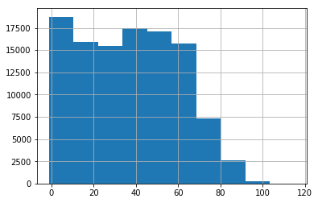

```python
# Checking how 'Age' column distributes overall
df['Age'].hist();
```

It was observed that the patients' ages range from 0 to over 100 years, with uneven distribution across different age groups. To accurately address question 2, we will utilize the mean age to segment the age groups and determine the corresponding proportions.

```python
# Checking mean age
df['Age'].mean()
```

```
37.088874211731067
```

We will need mean age to divide two differnet age groups later - age groups older than 37 and younger than or equal to 37.

```python
# Checking the proportion of women and men.
df['Gender'].value_counts()
```

```
F    71840
M    38687
Name: Gender, dtype: int64
```

This step is needed to answer question 3. It seems no values other than 'F' and 'M' included, so no furthur cleaning steps will be conducted for this column. Also, female patients are significantly more than male patients, we will need to calculate the proportions later to find out the correlation correctly.

### Data Cleaning

```python
# Change datatype of 'PatientId' column to the correct int format and
# double check if it presents correctly.
df['PatientId'] = df['PatientId'].astype(int)
print(df['PatientId'])
```

```
0          29872499824296
1         558997776694438
2           4262962299951
3            867951213174
4           8841186448183
5          95985133231274
6         733688164476661
7           3449833394123
8          56394729949972
9          78124564369297
10        734536231958495
11          7542951368435
12        566654781423437
13        911394617215919
14         99884723334928
```

[output cut: 47 more lines]

As we discussed before, PatientId column needed to be converted from scientific notation to an int format in order to present it correctly.

```python
#Create dataframe for no-show appointments only
df_no_show = df[df['No-show'] == 'Yes']

#Calculate total no-show appointments.
no_show_apt = df_no_show['AppointmentID'].nunique()

#Calculate total no-show appointments for people who received SMS messages.
no_show_sms = df_no_show[df_no_show['SMS_received'] == 1]['AppointmentID'].nunique()

# proportion for no-show appointments for people who received SMS messages.
sms_ns_prop = no_show_sms / no_show_apt

# proportion for no-show appointments for people who did not receive
# SMS messages.
no_show_no_sms = df_no_show[df_no_show['SMS_received'] == 0]['AppointmentID'].nunique()
nsms_ns_prop = no_show_no_sms / no_show_apt
```

Form this step, in order to answer question 1, we calculated both proportions that people did receive sms messages and people did not receive sms messages to study how they effect no-show appointments.

```python
# Separate the age groups from the mean age(37) that we calculated before
# For age group over 37
age_group_a = df[df['Age'] > 37]
# For age group less than or equal to 37
age_group_b = df[df['Age'] <= 37]

# Create two dataframes for 'No' and 'Yes' values in the 'No-show' column for age > 37
no_show_yes_a = age_group_a[age_group_a['No-show'] == 'Yes']

# Create two dataframes for 'No' and 'Yes' values in the 'No-show' column for age <= 37
no_show_yes_b = age_group_b[age_group_b['No-show'] == 'Yes']

# Calculate the number of unique Appointment IDs for each group
no_show_no_counts_a = no_show_yes_a['AppointmentID'].nunique()
no_show_no_counts_b = no_show_yes_b['AppointmentID'].nunique()

#Proportions for each group
no_show_a = no_show_no_counts_a / no_show_apt
no_show_b = no_show_no_counts_b / no_show_apt
```

```python
#Calculate total appointments for females
total_appt_f = df[df['Gender'] == 'F']['AppointmentID'].nunique()
#Calculate total female patients who had no-show appoinments
no_show_f = df[(df['Gender'] == 'F') & (df['No-show'] == 'Yes')]['AppointmentID'].nunique()
#Calculate the female proportion for having no-show appointments
f_prop = no_show_f / total_appt_f
```

```python
#Calculate total appointments for males
total_appt_m = df[df['Gender'] == 'M']['AppointmentID'].nunique()
#Calculate total male patients who had no-show appoinments
no_show_m = df[(df['Gender'] == 'M') & (df['No-show'] == 'Yes')]['AppointmentID'].nunique()
#Calculate the male proportion for having no-show appointments
m_prop = no_show_m / total_appt_m
```

Form the two steps above, we can answer answer quetsion 3, we calculated proportions for male patients who did not show up for appointments in total male patients, and female patients who did not show up for appointments in total female patients. As we explored before, the total patients for male and female are very different, so that we needed to calculate the proportion instead of directly using the value counts.

## Exploratory Data Analysis

## 1. Was there a lower likelihood of appointment no-shows among individuals who received SMS text messages compared to those who did not receive them?

[figure not shown]

```python
# Data for the plot
proportions = [sms_ns_prop, nsms_ns_prop]
labels = ['SMS Received', 'No SMS Received']

# Create the bar plot
plt.bar(labels, proportions)
plt.xlabel('SMS Received')
plt.ylabel('Proportion of No-Show Appointments')
plt.title('Proportion of No-Show Appointments by SMS Received')

plt.gca().yaxis.set_major_formatter(mticker.PercentFormatter(1.0))
```

## 2. Was there a correlation between individuals aged over 37 (mean age) and their tendency to miss appointments, in comparison to those who were younger?

[figure not shown]

```python
# Define the data for the bar plot
groups = ['Age > 37', 'Age <= 37']
proportions = [no_show_a, no_show_b]

# Create the bar plot
plt.bar(groups, proportions)
plt.xlabel('Age Group')
plt.ylabel('Proportion of No-show Appointments')
plt.title('Proportion of No-show Appointments by Age Group')

plt.gca().yaxis.set_major_formatter(mticker.PercentFormatter(1.0))
```

## 3. Was there a greater inclination among women or men to fail to show up for their appointments?

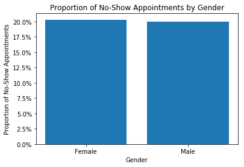

```python
# Data for the plot
proportions = [f_prop, m_prop]
labels = ['Female', 'Male']

# Create the bar plot
plt.bar(labels, proportions)

# Add labels and title
plt.xlabel('Gender')
plt.ylabel('Proportion of No-Show Appointments')
plt.title('Proportion of No-Show Appointments by Gender')
# Format y-axis tick labels as percentages
plt.gca().yaxis.set_major_formatter(mticker.PercentFormatter(1.0));
```

## Conclusions

Observations from the Analysis:

1. SMS Messages and Appointment Attendance: The data reveals that individuals who received SMS messages demonstrate a higher tendency to show up for appointments. Specifically, the proportion of no-show appointments is 13% lower among those who received SMS messages compared to those who did not.
2. Age and Appointment Attendance: A notable finding is that individuals who are under or equal to the mean age of 37 exhibit a higher likelihood of missing appointments compared to those who are older than 37.
3. Gender Disparity in No-show Appointments: Despite having a larger number of female patients in the dataset, the proportion of females in no-show appointments is only marginally higher than that of males, with a difference of just 0.34%.

Key Findings:

SMS messages have a positive impact on appointment attendance, resulting in a lower proportion of no-shows. Age plays a role in appointment attendance, with younger individuals demonstrating a higher tendency to miss appointments compared to older individuals. Gender disparity in no-show appointments is minimal, indicating a similar likelihood of males and females missing their appointments.